# Implementation of a sugar tax for SSBs

Karin Altvater, Santosh Bhandari, Patrick Frey, Sanghyo Moon

2023-07-14

## Introduction

### What are Sugar-Sweetened Beverages (SSBs)?

- soft drinks, energy drinks, fruit nectar drinks etc.
- one of the main sources of added sugar intake in Germany
- many associated health issues, that lead to a decrease in life quality of individual people and are also a burden on the public health system (Backholer, Blake, and Vandevijvere (2022))

### And why should they be taxed?

- to internalize the external costs of high sugar consumption for the society
- higher prices of SSBs lead to lower consumption: proven for several countries
  - a 10% tax has been shown to lead to an 8-10% reduction in purchase and consumption of SSBs
  - a 20% tax has been demonstrated to reduce the prevalence of overweight by 1-3% and the prevalence of obesity by 1-4%
  - SSB taxes can significantly reduce the incidence of other health issues like diabetes type 2
  - SSB taxes have resulted in substantial increases in government revenue
  - no evidence of negative impact on employment was found (Backholer, Blake, and Vandevijvere (2022))
- tax returns can be reinvested in health sector, further promoting health and well-being of the population
- alternative interventions to reduce sugar consumption on the individual and producer/retailer level often show effects slower and are more costly; they are still useful to accompany a tax introduction
- WHO and UNICEF recommend the introduction of a SSB tax (Backholer, Blake, and Vandevijvere (2022))

### Why did we choose Germany?

- Germany doesn’t have this kind of tax at the moment
- officially because “there is not enough scientifical evidence yet that a tax on SBBs will decrease sugar or total energy intake of the population in the long term and/or decrease obesity” (Deutscher Bundestag 2020)
- Instead, Germany has a national strategy ([NRI, 2019-25](https://www.bmel.de/SharedDocs/FAQs/DE/faq-reduktionsstrategieZuckerSalzFette/FAQ-reduktionsstrategieZuckerSalzFette_List.html)) including the reduction of sugar contents of heavily processed food/drinks and awareness raising campaigns

[output not shown]

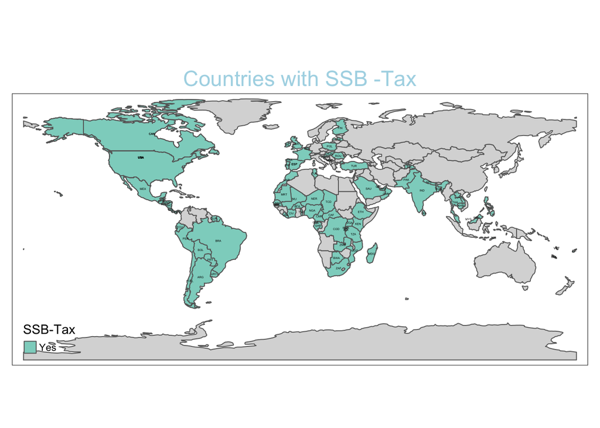

The data is according to FAOSTAT 2023.

For visualization, we used the package ‘tmap’ (Tennekes 2022).

## Decision

**Decision:** Introducing a tax on SSBs in Germany

**Decision maker:** German government

### Underlying assumptions of the model

- higher prices lead to lower consumption of SSBs
  - important to declare the tax separately on the label and explain about negative health consequences to make the tax more effective
  - awareness raising campaigns and public information also important
  - some people might feel patronized and consume even more
- lower consumption of SSBs leads to lower consumption of sugar
  - people might substitute with other sugar-rich products

## Model: Broad approach

In our overall decision model, we are looking at all the possible effects that come from implementing a tax on SSBs. These include economic, ecologic, social and health factors. From an economic point of view, the implementation of an SSB tax might decrease earnings of stakeholders along the value chain of SSB production and sale. This starts with sugar beet cultivators, who might have to abandon sugar beet production or at least reduce it. From an ecological perspective, reduced sugar beet cultivation might free space for more sustainable cultivation of other crops or biodiversity conservation measures. It might increase soil health, as the cultivation of sugar beets, especially over a long period of time, was found to be deleterious to the soil. Finally, considering the social aspect, an SSB tax could lead to demonstrations by people who feel patronized by it. There is also the question if an artificial price rise is ethically justifyable or if this is a discrimination of poorer households.

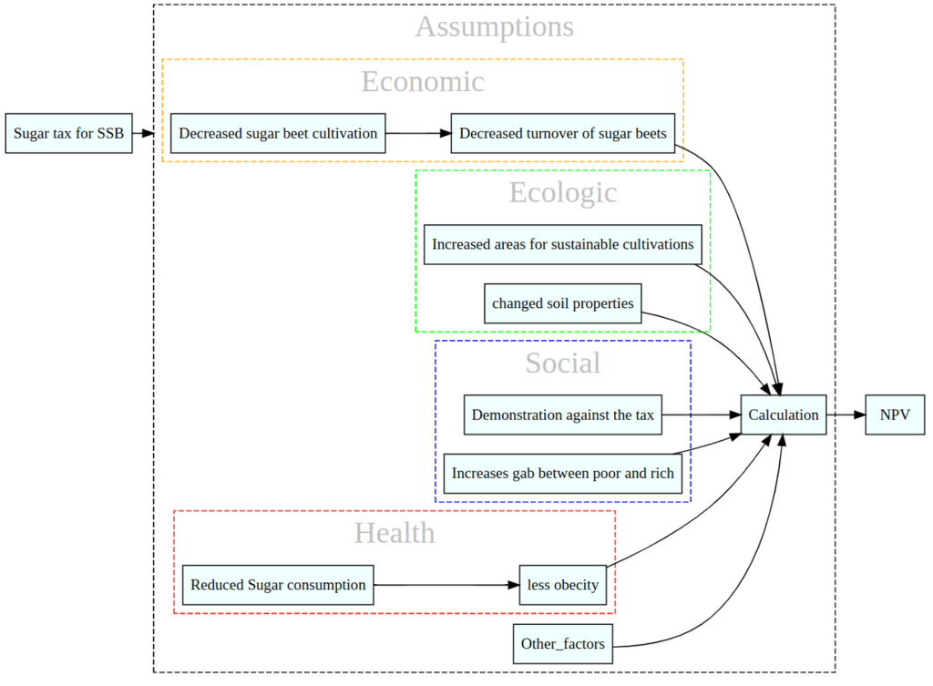

To decrease complexity and develop a comprehensive decision model, we focus on the effects that an SSB tax might have on health outcomes. We assume that higher prices of SSBs lead to lower consumption and therefore reduced sugar intake, leading to fewer cases of sugar consumption related health issues like diabetes, obesity and cancer.

## Model: Health Care Cost

The german government will make the decision of introducing a SSB tax if this will save them expenses. For our model, we are simulating the effects of a tax over a 10 year period. Costs of a tax for the government encompass administration costs and costs for public information and awareness raising campaigns for the first year. For each consecutive year, there will be maintenance costs. Savings in expenses for the government will come from reduced incidences of diabetes, obesity and cancer and the related saved spendings on treatments. Furthermore, there will be tax revenues.

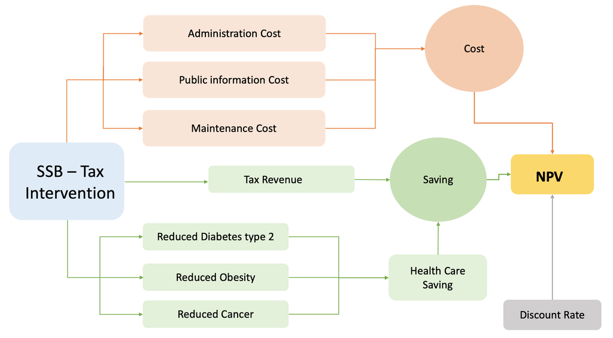

At the end, the total NPV will be calculated based on these costs and benefits which will help us to decide whether to implement a SSB tax or not.

## Input table

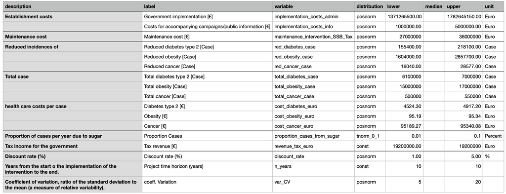

```r
input_table
```

Based on (Du et al. 2021), (Sánchez-Romero et al. 2016) and (Lal et al. 2017)

## Calculation

```r
library(decisionSupport)

decision_function <- function(x, varnames){
  # total health care cost related to sugar consumption: type 2 diabetes, cancer and obesity
  # proportion_cases_from_sugar is assumption of relation between sugar consumption and disease

  cost_diabetes <-vv(total_diabetes_case*proportion_cases_from_sugar, var_CV, n_years)*
    vv(cost_diabetes_euro, var_CV, n_years)

  cost_obesities <- vv(total_obesity_case*proportion_cases_from_sugar, var_CV, n_years)*
    vv(cost_obesity_euro, var_CV, n_years)

  cost_cancer <- vv(total_cancer_case*proportion_cases_from_sugar, var_CV, n_years)*
    vv(cost_cancer_euro, var_CV, n_years)

  total_health_care_cost <- cost_diabetes + cost_obesities + cost_cancer

  # pre-calculate common random draws for all intervention model runs ####
  #health care cost after implementation of tax and Tax revenue

  precalc_HC_with_interv_Tax_DI <- (vv(total_diabetes_case*proportion_cases_from_sugar, var_CV, n_years)*
                                      vv(cost_diabetes_euro, var_CV, n_years)) -
    (vv(red_diabetes_case*proportion_cases_from_sugar, var_CV, n_years)* vv(cost_diabetes_euro, var_CV, n_years))

  precalc_HC_with_interv_Tax_OB <-  (vv(total_obesity_case*proportion_cases_from_sugar, var_CV, n_years)*
                                       vv(cost_obesity_euro, var_CV, n_years))-
    (vv(red_obesity_case*proportion_cases_from_sugar, var_CV, n_years)*vv(cost_obesity_euro, var_CV, n_years))

  precalc_HC_with_interv_Tax_CA <- (vv(total_cancer_case*proportion_cases_from_sugar, var_CV, n_years)*
                                      vv(cost_cancer_euro, var_CV, n_years))-
    (vv(red_cancer_case*proportion_cases_from_sugar, var_CV, n_years)*vv(cost_cancer_euro, var_CV, n_years))

  precalc_tax_revenue <- vv(revenue_tax_euro, var_CV, n_years)


  ###Intervention of implementation SSB Tax ###

  for (decision_implementation_SSB_Tax in c(FALSE,TRUE)){

    if (decision_implementation_SSB_Tax){

      implementation_SSB_Tax <- TRUE
      implementation_admin <- TRUE
      no_implementation <- FALSE

    } else
    {
      implementation_SSB_Tax <- FALSE
      implementation_admin <- FALSE
      no_implementation <- TRUE

    }


    ##cost for intervention##
    if (implementation_admin){
      cost_implementation_govern <-
        implementation_costs_admin + implementation_costs_info
    } else{
      cost_implementation_govern <- 0
    }

    # calculating the maintenance costs, initializing the array with 0 costs for the first year:
    maintenance_cost <- rep(0, n_years)

    if (implementation_SSB_Tax){
      maintenance_cost <-
        maintenance_cost + vv(maintenance_intervention_SSB_Tax,
                              var_CV, n_years)

      intervention_cost <- maintenance_cost

      #intervention cost for first year
      intervention_cost[1] <-
        cost_implementation_govern
    }


    # health care cost after SSB Tax  ####

    implementation_SSB_Tax_Di <-
      as.numeric(implementation_SSB_Tax) * precalc_HC_with_interv_Tax_DI
    implementation_SSB_Tax_OB <-
      as.numeric(implementation_SSB_Tax) * precalc_HC_with_interv_Tax_OB
    implementation_SSB_Tax_Ca <-
      as.numeric(implementation_SSB_Tax) * precalc_HC_with_interv_Tax_CA


    total_healthcare_cost_with_SSB_Tax <-
      implementation_SSB_Tax_Di + implementation_SSB_Tax_OB + implementation_SSB_Tax_Ca

    implementation_SSB_Tax_tax_revenue <-
      as.numeric(implementation_SSB_Tax) * precalc_tax_revenue

    #Health care cost without SSB Tax

    cost_diabetes_no_SSB_Tax <-  as.numeric(no_implementation)*cost_diabetes

    cost_obesities_no_SSB_Tax <- as.numeric(no_implementation)* cost_obesities

    cost_cancer_no_SSB_Tax <- as.numeric(no_implementation)*cost_cancer

    total_health_care_cost_no_SSB_Tax <-
      cost_diabetes_no_SSB_Tax + cost_obesities_no_SSB_Tax + cost_cancer_no_SSB_Tax


    if(implementation_SSB_Tax){
      imple_tax_revenue <- implementation_SSB_Tax_tax_revenue
    } else imple_tax_revenue <- 0


    ## Total cost with SSB tax##
    if (decision_implementation_SSB_Tax){

      net_health_care_cost_with_imple <-
        total_healthcare_cost_with_SSB_Tax + intervention_cost - implementation_SSB_Tax_tax_revenue


      result_imple <- net_health_care_cost_with_imple
    }

    if (!decision_implementation_SSB_Tax){
      result_no_imple <- total_health_care_cost_no_SSB_Tax
    }

  }#close implementation

  #calculate NPV

  NPV_imple <-
    discount(result_imple, discount_rate, calculate_NPV = T)

  NPV_no_imple <-
    discount(result_no_imple, discount_rate, calculate_NPV = T)



  return(list(Imple_NPV =  - NPV_imple, #invert because this is the spending
              NO_Imple_NPV = - NPV_no_imple, #invert because this is the spending
              NPV_decision_SSB_Tax =  NPV_no_imple - NPV_imple, #how much they will save
              Cashflow_decision_SSB_Tax =  result_no_imple - result_imple)) #how much they will save
}
```

## Simulation

```r
library(readr)
input_table <- read.csv("input_table_updated_3.csv")


###Model assessment###
mcSimulation_results1 <- mcSimulation(estimate =
                                        estimate_read_csv("input_table_updated_3.csv"),
                                      model_function = decision_function,
                                      numberOfModelRuns = 1000,
                                      functionSyntax = "plainNames"
)
```

## Plots: Net present Value

The graphs show the results of a Monte Carlo simulation based on our model and input data, where the expected net present value and the comparison show what the government would spend in each scenario. We cannot see significant differences here, as the distribution is very widely spread, indicating high uncertainties in our model.

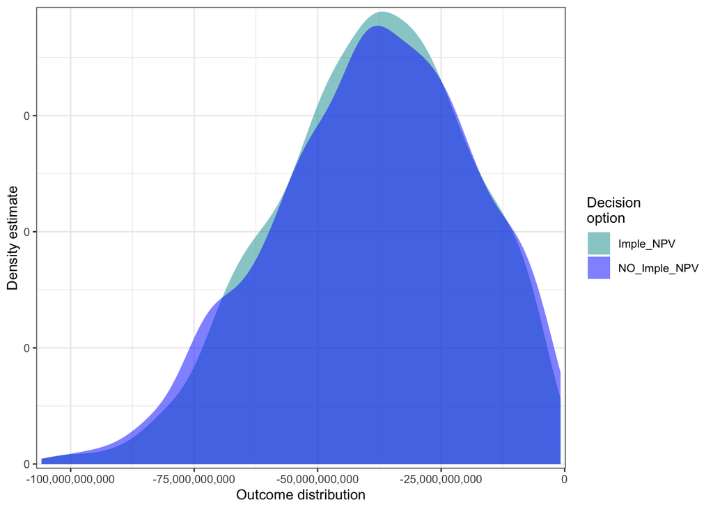

```r
plot_distributions(mcSimulation_object = mcSimulation_results1,
                   vars = c("Imple_NPV",
                            "NO_Imple_NPV"),
                   method = 'smooth_simple_overlay',
                   base_size = 10)
```

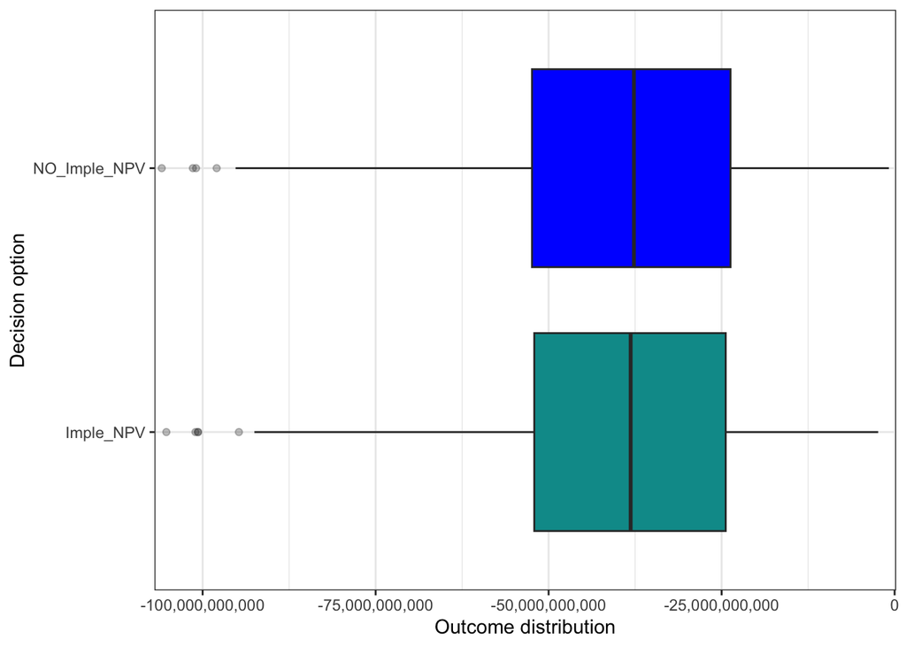

```r
decisionSupport::plot_distributions(mcSimulation_object = mcSimulation_results1,
                                    vars = c("Imple_NPV",
                                             "NO_Imple_NPV"),
                                    method = 'boxplot')
```

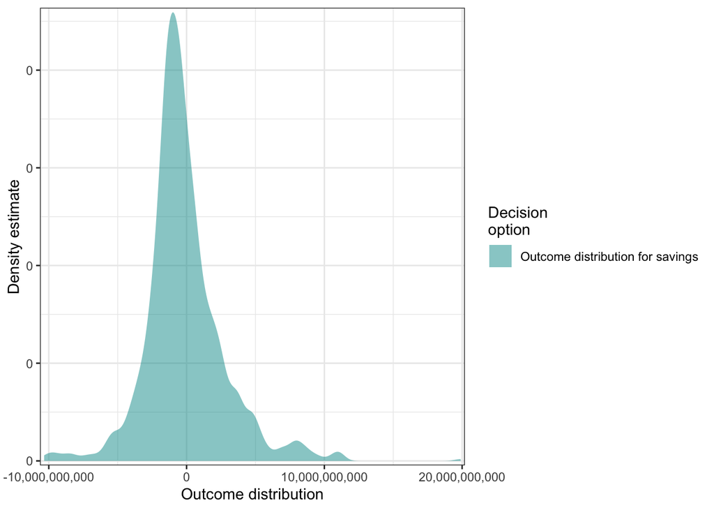

```r
decisionSupport::plot_distributions(mcSimulation_object = mcSimulation_results1,
                                    vars = "NPV_decision_SSB_Tax",
                                    method = "smooth_simple_overlay",
                                    old_names = "NPV_decision_SSB_Tax",
                                    new_names = "Outcome distribution for savings")
```

## Cashflow analysis

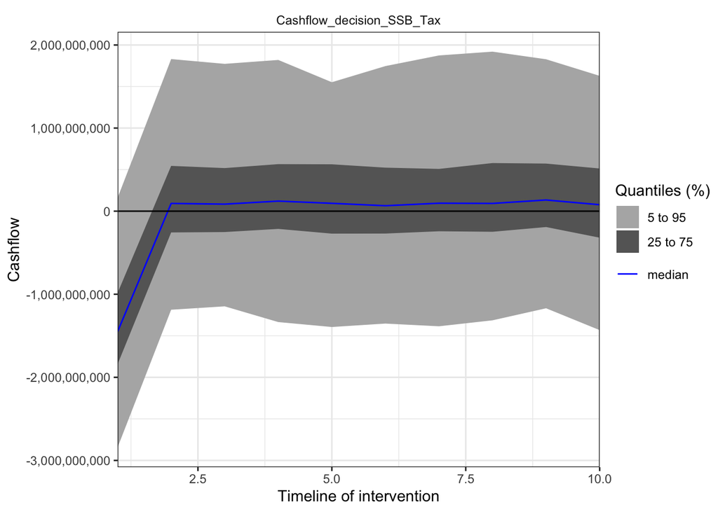

```r
plot_cashflow(mcSimulation_object = mcSimulation_results1,
              cashflow_var_name = "Cashflow_decision_SSB_Tax")
```

## Value of Information

```r
#here we subset the outputs from the mcSimulation function (y) by selecting the correct variables
# choose this carefully and be sure to run the multi_EVPI only on the variables that the you want
#EVPI = (EOL : Expected Opportunity Loss)


mcSimulation_table <- data.frame(mcSimulation_results1$x, mcSimulation_results1$y[1:3])

evpi <- multi_EVPI(mc = mcSimulation_table, first_out_var = "Imple_NPV")
```

```
## [1] "Processing 3 output variables. This can take some time."
## [1] "Output variable 1 (Imple_NPV) completed."
## [1] "Output variable 2 (NO_Imple_NPV) completed."
## [1] "Output variable 3 (NPV_decision_SSB_Tax) completed."
```

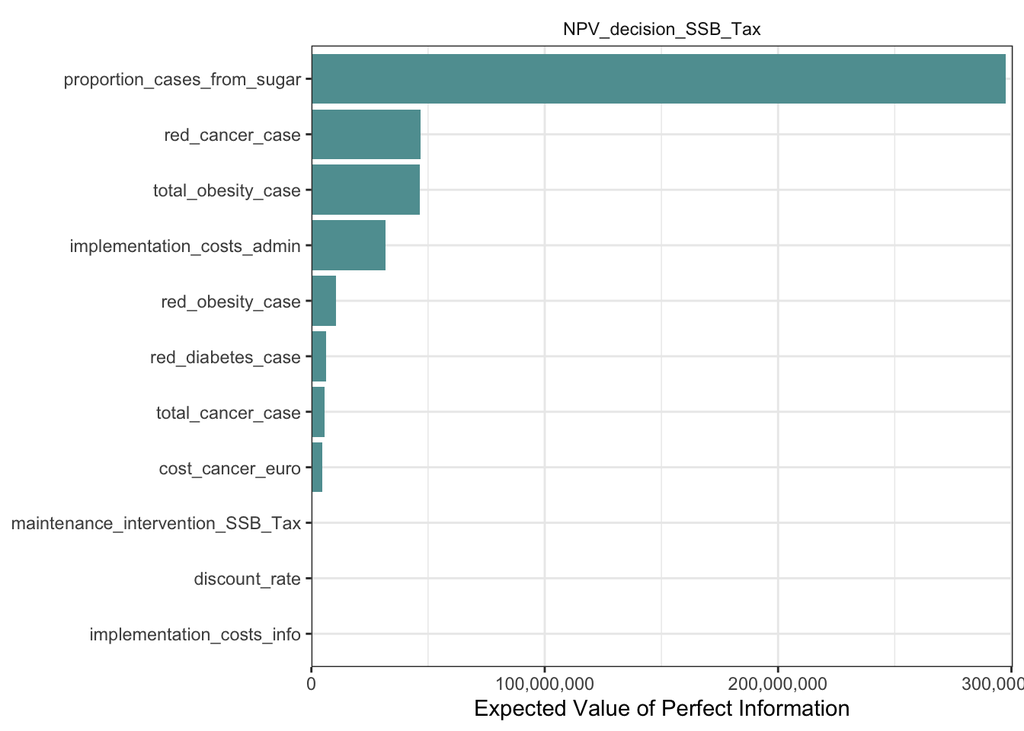

```r
plot_evpi(evpi, decision_vars = "NPV_decision_SSB_Tax")
```

## Plot of NPV, Cashflow and VoI

In the graph on the bottom left we determine the Variable Importance in the Projection (VIP) for our model variables. At the X-axis value = 1, we see the threshold between important and unimportant variables for the model output. We also see the importance of the proportion of disease cases per year related to sugar.

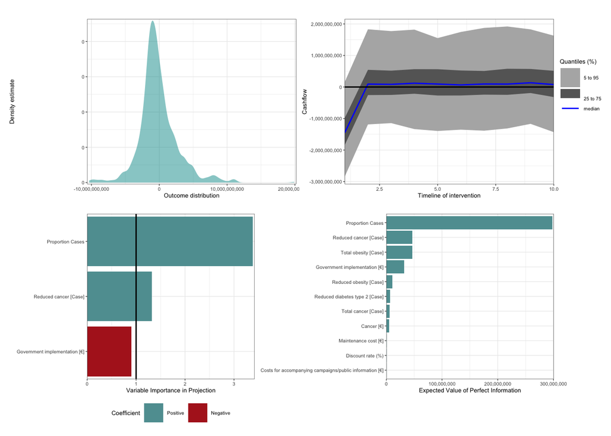

```r
#put here mcSimulation_result instead of pls_result
compound_figure(mcSimulation_object = mcSimulation_results1,
                input_table = input_table,
                plsrResults = mcSimulation_results1,
                EVPIresults = evpi, decision_var_name = "NPV_decision_SSB_Tax",
                cashflow_var_name = "Cashflow_decision_SSB_Tax",
                base_size = 5)
```

## Projection to Latent Structures

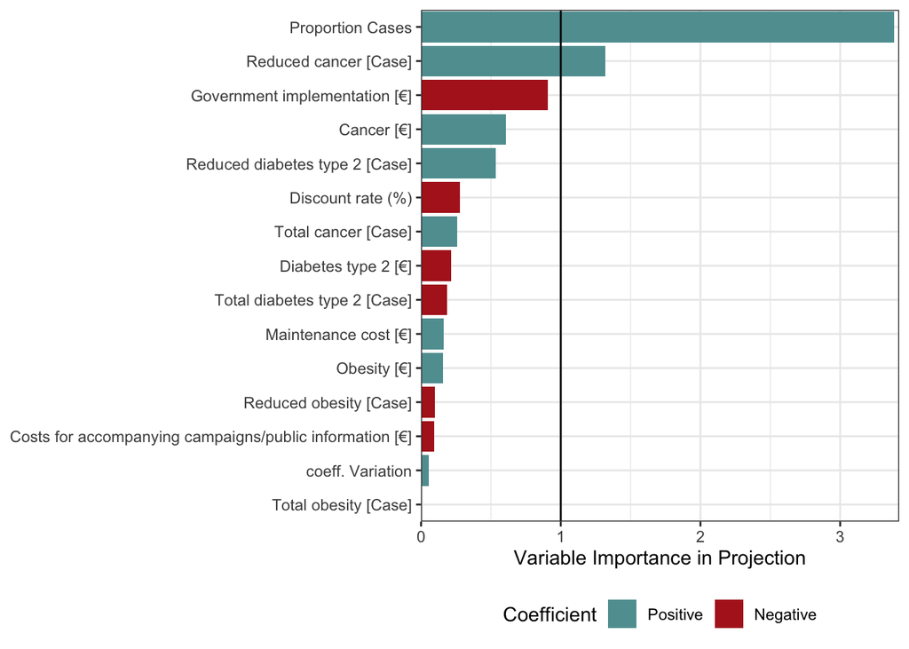

```r
pls_result <- plsr.mcSimulation(object = mcSimulation_results1,
                                resultName = names(mcSimulation_results1$y)[3], ncomp = 1)
plot_pls(pls_result, input_table = input_table, threshold = 0)
```

## Conclusion

- We did not choose an easy decision
- Many underlying assumptions that are difficult to prove (causal effects)
- Complex calculations that need a lot of input data
- High uncertainties
- Much more research needed

To see all the data we used, please visit our [GitHub-Repository](https://github.com/SHMooon/nutrition)

## Sources

Backholer, K.;, M.; Blake, and S Vandevijvere. 2022. “Sugar-sweetened beverage taxation.” *Public Health Nutrition (Unicef)* 20: 3219–24.

Deutscher Bundestag. 2020. “Deutscher Bundestag Antwort Grüne.” *Antwort Der Bundesregierung - Parkraumbewirtschaftung in Die Hand Der Städte Und Gemeinden*, no. 15/2302: 1–4.

Du, Mengxi, Christina F. Griecci, David D. Kim, Frederick Cudhea, Mengyuan Ruan, Heesun Eom, John B. Wong, et al. 2021. “Cost-effectiveness of a national sugar-sweetened beverage tax to reduce cancer burdens and disparities in the united states.” *JNCI Cancer Spectrum* 4 (6): 1–12. https://doi.org/10.1093/JNCICS/PKAA073.

Lal, Anita, Ana Maria Mantilla-Herrera, Lennert Veerman, Kathryn Backholer, Gary Sacks, Marjory Moodie, Mohammad Siahpush, Rob Carter, and Anna Peeters. 2017. “Modelled health benefits of a sugar-sweetened beverage tax across different socioeconomic groups in Australia: A cost-effectiveness and equity analysis.” *PLoS Medicine* 14 (6): 1–17. https://doi.org/10.1371/journal.pmed.1002326.

Sánchez-Romero, Luz Maria, Joanne Penko, Pamela G. Coxson, Alicia Fernández, Antoinette Mason, Andrew E. Moran, Leticia Ávila-Burgos, Michelle Odden, Simón Barquera, and Kirsten Bibbins-Domingo. 2016. “Projected Impact of Mexico’s Sugar-Sweetened Beverage Tax Policy on Diabetes and Cardiovascular Disease: A Modeling Study.” *PLoS Medicine* 13 (11): 1–17. https://doi.org/10.1371/journal.pmed.1002158.

Tennekes, Martijn. 2022. *Tmap: Thematic Maps*. https://github.com/r-tmap/tmap.

WHO. 2022. *WHO manual on sugar-sweetened beverage taxation policies to promote healthy diets*. https://www.who.int/publications/i/item/9789240056299.